# Lab 04: Uncertainty & Error

Ednita Tavarez-Jimenez

## Normal Vectors

Q1: Create four vectors of normally-distributed random numbers, norm_17, norm_30, norm_300, and norm_3000.

You should tell R that you want your random deviates have a mean of 10.4 and a standard deviation of 2.4.

norm_17 should have 17 elements, norm_30 should have 30 elements, norm_300 should have 300 elements, and norm_3000 should have 3000 elements.

(1 pt.) Show the code you used to create your vectors.

```r
#norm_17

set.seed(39)
norm_17 <- rnorm(17, mean = 10.4, sd = 2.4)

#norm_30

set.seed(39)
norm_30 <- rnorm(30, mean = 10.4, sd = 2.4)

#norm_300

set.seed(35)
norm_300 <- rnorm(300, mean = 10.4, sd = 2.4)

#norm_3000

set.seed(39)
norm_3000 <- rnorm(3000, mean = 10.4, sd = 2.4)
```

## Normal Vectors: Histograms

Q4: Qualitatively describe the differences among the histograms.

Q5: Explain why the shapes of the histograms are different.

The shapes are so different because they are each generating a set value of random numbers and they each only generate a certain amount.

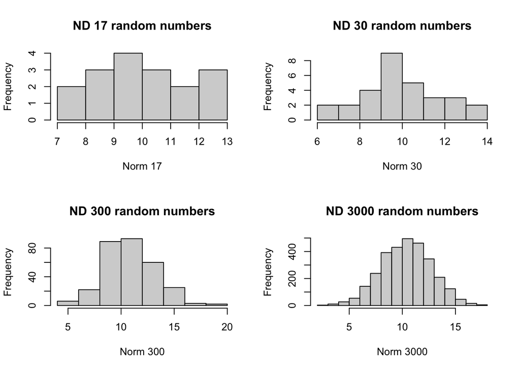

```r
#png(file = "ND Random Numbers)", width = 1000, height = 1000)
par(mfrow = c(2, 2))
hist(norm_17, main = "ND 17 random numbers", xlab = "Norm 17")
hist(norm_30, main = "ND 30 random numbers", xlab = "Norm 30")
hist(norm_300, main = "ND 300 random numbers", xlab = "Norm 300")
hist(norm_3000, main = "ND 3000 random numbers", xlab = "Norm 3000")
```

```r
#dev.off()
```

## Standard Normal

Q6: What are the parameters and their values for the standard Normal distribution?

the parameters for the standard Normal distribution are mean 0 and sd = 1

Q7: Normal Density Function

Include the R code you used to create your figure. Your answer should include code that builds the figure as well as saves it to a file.

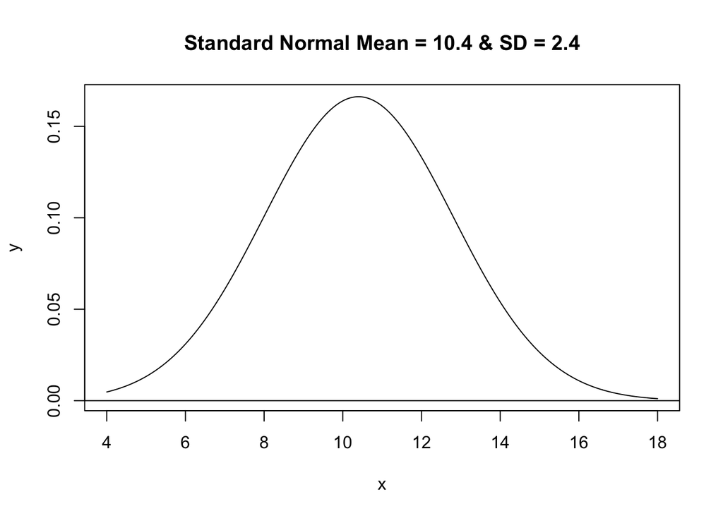

```r
# Generate a vector of x-values
#pdf(file = "Standard Normal Graph.pdf", width = 7, height = 7)
x = seq(4, 18, length.out = 1000)
y = dnorm(x, mean = 10.4, sd = 2.4)
plot(x, y, main = "Standard Normal Mean = 10.4 & SD = 2.4", type = "l", xlim = c(4, 18))
abline(h = 0)
```

```r
#dev.off()
```

## Random Data

*Q9: Show the R code you used to create one of the random datasets in your figure.

[figure not shown]

```r
#norm_11

set.seed(5)
rnorm_1 <- rnorm(15, mean = 4.2, sd = 2.2)

#norm_111

set.seed(10)
rnorm_11 <- rnorm(11, mean = 4.2, sd = 2.2)

#norm_1111

set.seed(100)
rnorm_111 <- rnorm(111, mean = 4.2, sd = 2.2)

#norm_11111

set.seed(1000)
rnorm_1111 <- rnorm(1111, mean = 4.2, sd = 2.2)


#plot
par(mfrow = c(2, 2))
barplot(rnorm_1, main = "RNorm 11 Random Numbers", xlab = "rnorm 11", col = "pink")
hist(rnorm_11, main = "RNorm 111 Random Numbers", xlab = "rnorm 111", col = "steelblue")
boxplot(rnorm_111, main = "RNorm 1111 Random Numbers", xlab = "rnorm 1111", col = "red")
plot(rnorm_1111, main = "RNorm 111111 Random Numbers", xlab = "rnorm 11111", col = "chartreuse4")
```

*Q10:

```r
pdf(file = "Random Data Graphs Q9 - Q10", width = 7, height = 7)
par(mfrow = c(2, 2))
barplot(rnorm_1, main = "RNorm 11 Random Numbers", xlab = "rnorm 11", col = "pink")
hist(rnorm_11, main = "RNorm 111 Random Numbers", xlab = "rnorm 111", col = "steelblue")
boxplot(rnorm_111, main = "RNorm 1111 Random Numbers", xlab = "rnorm 1111", col = "red")
plot(rnorm_1111, main = "RNorm 111111 Random Numbers", xlab = "rnorm 11111", col = "chartreuse4")
dev.off()
```

## Random Data Model Fit

Choose one of the datasets you created for the previous question. Adapting the code in the lab walkthrough, visually fit a linear deterministic function through the data. Make sure you save your parameters to variables so you can use them in the next question. Create a plot of your simulated data and your fitted linear model.

Q11 Random Data Model Fit (Q 13-14) (3 pts.) Show the R code you used to create one of the random datasets in your figure.

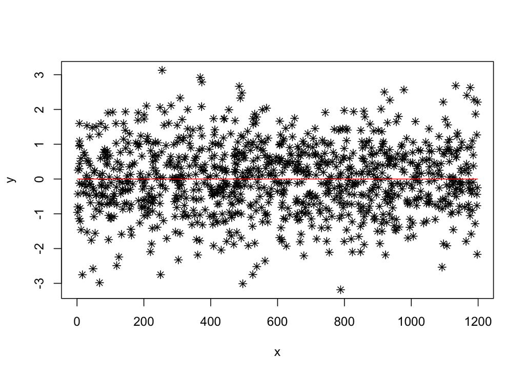

```r
n_pts = 1000
x_min = 0
x_max = 1200

# X values are uniformly distributed
x_random = runif(n = n_pts, min = x_min, max = x_max)

# Y values are normally-distributed.
# I used the default parameters for mean and sd.
y_random = rnorm(n = n_pts)

dat_random = data.frame(x = x_random, y = y_random)

plot(y ~ x, data = dat_random, pch = 8)

line_point_slope = function(x, x1, y1, slope)
{
  get_y_intercept =
    function(x1, y1, slope)
      return(-(x1 * slope) + y1)

  linear =
    function(x, yint, slope)
      return(yint + x * slope)

  return(linear(x, get_y_intercept(x1, y1, slope), slope))
}
guess_x <- 600
guess_y <- 0
guess_slope <- 0
plot(y ~ x, data = dat_random, pch = 8)
curve(line_point_slope(x, guess_x, guess_y, guess_slope), add = T, col = "red")
```

Q12: Upload an image file of your figure. It may be in png (raster graphics), svg (vector graphics), or pdf (vector graphics) format. Check out the corresponding functions png(), pdf(), and svg() for info.

```r
pdf(file = "Curve Plot", width = 7, height = 7)
guess_x <- 600
guess_y <- 0
guess_slope <- 0
plot(y ~ x, data = dat_random, pch = 8)
curve(line_point_slope(x, guess_x, guess_y, guess_slope), add = T, col = "red")

dev.off()
```

## Random Data Model Residuals

Use the dataset you chose for the previous question. Adapting the code in the lab walkthrough, create a column of predicted y-values. Adapting the code in the lab walkthrough, create a column of residuals.

*Q13: Random Data Model Residuals*

Paste the R code you used to create create the columns of predicted values and residuals.

```r
line_point_slope(dat_random$x, guess_x, guess_y, guess_slope)
```

[output not shown]

```r
dat_random$y_predicted = line_point_slope(dat_random$x, guess_x, guess_y, guess_slope)
dat_random$resids = (dat_random$y - dat_random$y_predicted)
head(dat_random)
```

```
##          x          y y_predicted     resids
## 1 102.4288 -1.1289888           0 -1.1289888
## 2 430.5688  0.9628394           0  0.9628394
## 3 678.2074  1.0075003           0  1.0075003
## 4 542.1964  0.3057322           0  0.3057322
## 5 301.1703 -0.5863045           0 -0.5863045
## 6 612.5035 -0.8132227           0 -0.8132227
```

**Q14: Random Data Model Residuals**

In your report, include the two following figures A histogram of the model’s residuals. A scatterplot of your model’s predicted values (on the x-axis) and residuals (on the y-axis). Make sure your figure has appropriate title, legend, and other annotation as needed.

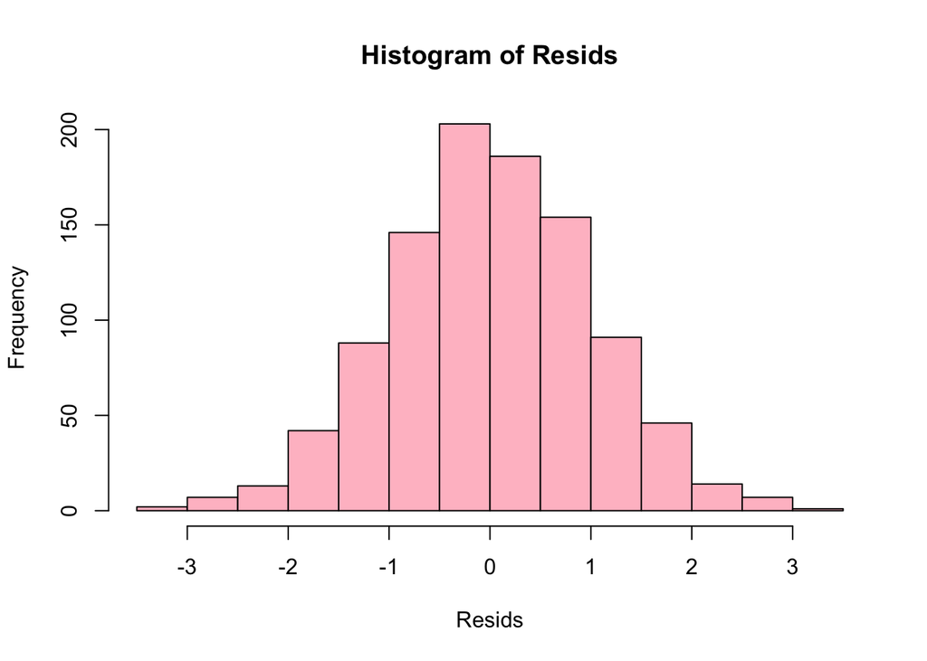

```r
dat_predict <- dat_random$y_predicted
dat_resids <- dat_random$resids
group <- as.factor(ifelse(dat_random < 0.5, "dat_predict", "dat_resids"))
hist(dat_resids, main = "Histogram of Resids", xlab = "Resids", col = "pink")
```

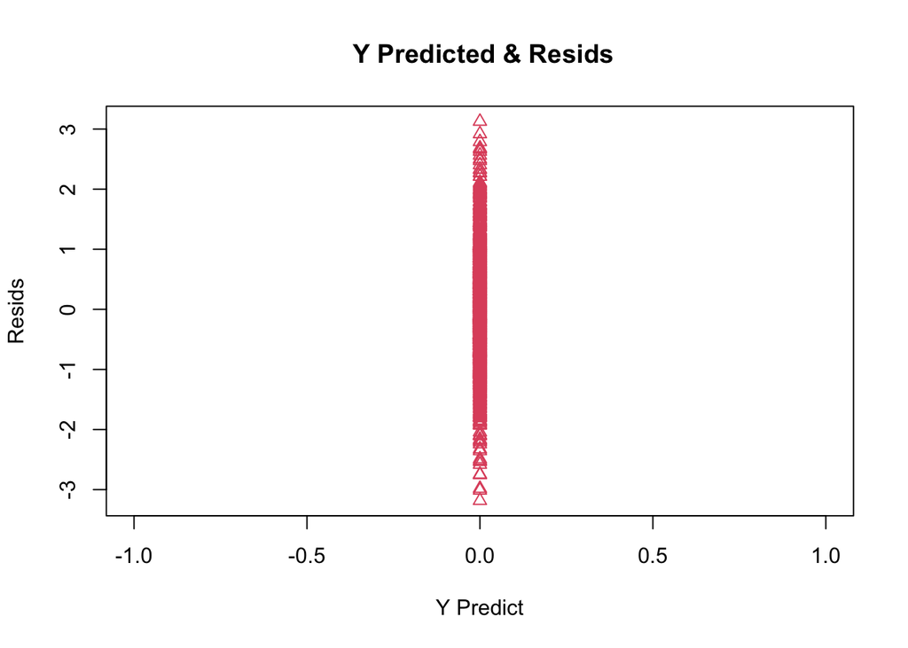

```r
plot(x = dat_predict, y = dat_resids, pch = as.numeric(group), main = " Y Predicted & Resids", xlab = "Y Predict", ylab = "Resids", col = factor(group))
```